# Gapminder data prep

meike

February 03, 2020

# 1 Datasets

| R name | file name | year subsetted |
| --- | --- | --- |
| LifeExpectancyYrs | life_expectancy_years.csv | 2011 |
| FemaleLiteracyRate | literacy_rate_adult_female_percent_of_females_ages_15_above.csv | 2011 |
| WaterSourcePrct | at_least_basic_water_source_overall_access_percent.csv | 2011 |
| CO2emissions | raw_data/co2_emissions_tonnes_per_person.csv |  |
| ElectricityUsePP | raw_data/electricity_use_per_person.csv |  |
| FoodSupplykcPPD | raw_data/food_supply_kilocalories_per_person_and_day.csv |  |
| IncomePP | raw_data/income_per_person_gdppercapita_ppp_inflation_adjusted.csv | up to 2040 |
| population | raw_data/population_total.csv | up to 2100 |

# 2 Life expectancy

- Complete data for 1970-2016

```
## [1] 187 220
```

## 2.1 skim

Data summary

| Name | LifeExpectancyYrs |
| --- | --- |
| Number of rows | 187 |
| Number of columns | 220 |
| _______________________ |  |
| Column type frequency: |  |
| character | 1 |
| numeric | 219 |
| ________________________ |  |
| Group variables | None |

**Variable type: character**

| skim_variable | n_missing | complete_rate | min | max | empty | n_unique | whitespace |
| --- | --- | --- | --- | --- | --- | --- | --- |
| country | 0 | 1 | 3 | 30 | 0 | 187 | 0 |

**Variable type: numeric**

| skim_variable | n_missing | complete_rate | mean | sd | p0 | p25 | p50 | p75 | p100 | hist |
| --- | --- | --- | --- | --- | --- | --- | --- | --- | --- | --- |
| x1800 | 3 | 0.98 | 31.50 | 3.81 | 23.40 | 29.08 | 31.75 | 33.82 | 42.9 | ▃▇▇▅▁ |
| x1801 | 3 | 0.98 | 31.46 | 3.81 | 23.40 | 28.98 | 31.65 | 33.90 | 40.3 | ▃▃▇▅▂ |
| x1802 | 3 | 0.98 | 31.48 | 3.94 | 23.40 | 28.90 | 31.55 | 33.82 | 44.4 | ▃▇▇▂▁ |
| x1803 | 3 | 0.98 | 31.38 | 3.96 | 19.60 | 28.90 | 31.50 | 33.62 | 44.8 | ▁▅▇▃▁ |
| x1804 | 3 | 0.98 | 31.46 | 3.93 | 23.40 | 28.98 | 31.55 | 33.73 | 42.8 | ▃▆▇▃▁ |
| x1805 | 3 | 0.98 | 31.59 | 4.01 | 23.40 | 29.08 | 31.65 | 33.82 | 44.3 | ▃▇▇▂▁ |
| x1806 | 3 | 0.98 | 31.64 | 4.11 | 23.40 | 29.08 | 31.75 | 33.92 | 45.8 | ▃▇▆▁▁ |
| x1807 | 3 | 0.98 | 31.60 | 3.98 | 23.40 | 29.08 | 31.75 | 33.92 | 43.6 | ▃▇▇▃▁ |
| x1808 | 3 | 0.98 | 31.38 | 4.09 | 12.50 | 28.98 | 31.55 | 33.73 | 43.5 | ▁▁▇▇▁ |
| x1809 | 3 | 0.98 | 31.31 | 4.04 | 13.40 | 28.87 | 31.50 | 33.62 | 41.7 | ▁▁▆▇▂ |
| x1810 | 3 | 0.98 | 31.54 | 3.88 | 23.40 | 29.08 | 31.75 | 33.82 | 43.1 | ▃▆▇▃▁ |
| x1811 | 3 | 0.98 | 31.50 | 3.80 | 23.40 | 29.08 | 31.65 | 33.82 | 40.1 | ▃▃▇▅▂ |
| x1812 | 3 | 0.98 | 31.49 | 3.90 | 23.00 | 29.08 | 31.70 | 33.82 | 43.5 | ▃▆▇▃▁ |
| x1813 | 3 | 0.98 | 31.48 | 3.81 | 23.40 | 29.08 | 31.65 | 33.73 | 43.0 | ▃▇▇▃▁ |
| x1814 | 3 | 0.98 | 31.54 | 3.86 | 23.40 | 29.08 | 31.65 | 33.92 | 41.7 | ▃▅▇▃▁ |
| x1815 | 3 | 0.98 | 31.68 | 4.13 | 23.40 | 29.08 | 31.75 | 34.00 | 45.6 | ▃▇▆▁▁ |
| x1816 | 3 | 0.98 | 31.66 | 4.12 | 23.40 | 29.08 | 31.65 | 33.92 | 46.3 | ▃▇▅▁▁ |
| x1817 | 3 | 0.98 | 31.76 | 4.33 | 23.40 | 29.08 | 31.75 | 34.00 | 48.9 | ▃▇▃▁▁ |
| x1818 | 3 | 0.98 | 31.60 | 4.65 | 5.50 | 29.08 | 31.75 | 34.00 | 46.8 | ▁▁▅▇▁ |
| x1819 | 3 | 0.98 | 31.50 | 4.65 | 1.50 | 29.08 | 31.75 | 34.00 | 45.8 | ▁▁▂▇▁ |
| x1820 | 3 | 0.98 | 31.58 | 4.56 | 6.50 | 29.15 | 31.75 | 34.00 | 47.0 | ▁▁▆▇▁ |
| x1821 | 3 | 0.98 | 31.65 | 4.05 | 23.40 | 29.15 | 31.65 | 33.92 | 44.7 | ▃▇▇▂▁ |
| x1822 | 3 | 0.98 | 31.76 | 4.29 | 23.40 | 29.15 | 31.80 | 34.00 | 48.4 | ▃▇▃▁▁ |
| x1823 | 3 | 0.98 | 31.81 | 4.39 | 23.40 | 29.15 | 31.80 | 34.00 | 48.8 | ▃▇▃▁▁ |
| x1824 | 3 | 0.98 | 31.75 | 4.22 | 23.40 | 29.15 | 31.80 | 34.00 | 47.6 | ▃▇▃▁▁ |
| x1825 | 3 | 0.98 | 31.70 | 4.18 | 23.40 | 29.15 | 31.80 | 34.00 | 49.2 | ▃▇▃▁▁ |
| x1826 | 3 | 0.98 | 31.62 | 4.09 | 23.40 | 28.98 | 31.75 | 34.00 | 47.6 | ▃▇▃▁▁ |
| x1827 | 3 | 0.98 | 31.66 | 4.19 | 23.40 | 28.98 | 31.75 | 34.00 | 48.4 | ▃▇▃▁▁ |
| x1828 | 3 | 0.98 | 31.60 | 4.00 | 23.40 | 28.98 | 31.75 | 34.00 | 46.2 | ▃▇▆▁▁ |
| x1829 | 3 | 0.98 | 31.58 | 3.95 | 23.40 | 29.15 | 31.75 | 34.00 | 46.3 | ▃▇▆▁▁ |

[output cut: 189 more lines]

## 2.2 years with fewest missing data

```
## # A tibble: 15 x 2
##    year  n_miss_LifeExpectancyYrs
##    <chr>                    <int>
##  1 x2016                        0
##  2 x2015                        0
##  3 x2014                        0
##  4 x2013                        0
##  5 x2012                        0
##  6 x2011                        0
##  7 x2010                        0
##  8 x2009                        0
##  9 x2008                        0
## 10 x2007                        0
## 11 x2006                        0
## 12 x2005                        0
## 13 x2004                        0
## 14 x2003                        0
## 15 x2002                        0
```

## 2.3 Restrict to 2011

- 2011 is year with most data for Adult female FemaleLiteracyRate rate

```
## # A tibble: 187 x 2
##    country             LifeExpectancyYrs
##    <chr>                           <dbl>
##  1 Afghanistan                      56.7
##  2 Albania                          76.7
##  3 Algeria                          76.7
##  4 Andorra                          82.6
##  5 Angola                           60.9
##  6 Antigua and Barbuda              76.9
##  7 Argentina                        76
##  8 Armenia                          73.8
##  9 Australia                        82.2
## 10 Austria                          80.7
## # … with 177 more rows
```

# 3 Literacy: Adult female FemaleLiteracyRate rate

```
## [1] 150  38
```

## 3.1 skim

Data summary

| Name | FemaleLiteracyRate |
| --- | --- |
| Number of rows | 150 |
| Number of columns | 38 |
| _______________________ |  |
| Column type frequency: |  |
| character | 1 |
| numeric | 37 |
| ________________________ |  |
| Group variables | None |

**Variable type: character**

| skim_variable | n_missing | complete_rate | min | max | empty | n_unique | whitespace |
| --- | --- | --- | --- | --- | --- | --- | --- |
| country | 0 | 1 | 3 | 24 | 0 | 150 | 0 |

**Variable type: numeric**

| skim_variable | n_missing | complete_rate | mean | sd | p0 | p25 | p50 | p75 | p100 | hist |
| --- | --- | --- | --- | --- | --- | --- | --- | --- | --- | --- |
| x1975 | 144 | 0.04 | 39.51 | 32.85 | 3.18 | 15.83 | 41.60 | 47.27 | 94.3 | ▇▃▇▁▃ |
| x1976 | 143 | 0.05 | 40.89 | 30.82 | 5.74 | 23.40 | 29.10 | 52.55 | 99.5 | ▇▂▅▁▂ |
| x1977 | 149 | 0.01 | 82.20 | NA | 82.20 | 82.20 | 82.20 | 82.20 | 82.2 | ▁▁▇▁▁ |
| x1978 | 148 | 0.01 | 62.45 | 50.70 | 26.60 | 44.53 | 62.45 | 80.38 | 98.3 | ▇▁▁▁▇ |
| x1979 | 143 | 0.05 | 30.45 | 28.71 | 4.99 | 9.06 | 12.00 | 49.95 | 78.1 | ▇▁▂▂▂ |
| x1980 | 133 | 0.11 | 71.34 | 22.52 | 12.20 | 59.10 | 74.80 | 88.00 | 98.5 | ▁▁▅▅▇ |
| x1981 | 134 | 0.11 | 58.22 | 29.22 | 9.15 | 34.25 | 70.75 | 82.25 | 95.5 | ▆▃▂▆▇ |
| x1982 | 143 | 0.05 | 59.99 | 27.07 | 17.50 | 41.80 | 71.80 | 78.10 | 90.8 | ▃▃▃▇▇ |
| x1983 | 148 | 0.01 | 80.15 | 12.09 | 71.60 | 75.88 | 80.15 | 84.43 | 88.7 | ▇▁▁▁▇ |
| x1984 | 146 | 0.03 | 47.50 | 31.59 | 19.30 | 31.67 | 39.05 | 54.88 | 92.6 | ▃▇▁▁▃ |
| x1985 | 144 | 0.04 | 79.72 | 13.98 | 64.20 | 68.73 | 78.55 | 91.38 | 95.9 | ▇▁▁▂▅ |
| x1986 | 146 | 0.03 | 52.52 | 19.48 | 31.40 | 38.60 | 53.10 | 67.03 | 72.5 | ▃▃▁▁▇ |
| x1987 | 147 | 0.02 | 51.60 | 29.38 | 33.50 | 34.65 | 35.80 | 60.65 | 85.5 | ▇▁▁▁▃ |
| x1988 | 146 | 0.03 | 27.43 | 13.97 | 17.90 | 19.70 | 21.85 | 29.57 | 48.1 | ▇▁▁▁▂ |
| x1989 | 140 | 0.07 | 95.81 | 4.82 | 82.80 | 96.22 | 96.70 | 98.10 | 99.6 | ▁▁▁▂▇ |
| x1990 | 135 | 0.10 | 76.07 | 18.88 | 27.50 | 68.30 | 83.00 | 88.60 | 96.2 | ▁▁▃▂▇ |
| x1991 | 129 | 0.14 | 66.70 | 27.94 | 8.22 | 44.80 | 74.00 | 89.30 | 99.5 | ▃▂▃▅▇ |
| x1992 | 141 | 0.06 | 73.84 | 24.87 | 16.60 | 71.30 | 78.50 | 91.00 | 95.0 | ▂▁▂▆▇ |
| x1993 | 146 | 0.03 | 58.20 | 36.54 | 4.59 | 50.12 | 73.25 | 81.33 | 81.7 | ▃▁▁▃▇ |
| x1994 | 138 | 0.08 | 59.13 | 30.63 | 17.10 | 31.18 | 61.15 | 89.17 | 99.1 | ▇▂▆▁▇ |
| x1995 | 145 | 0.03 | 81.20 | 20.89 | 47.90 | 74.20 | 89.20 | 96.40 | 98.3 | ▂▁▂▁▇ |
| x1996 | 142 | 0.05 | 62.00 | 37.47 | 8.06 | 35.14 | 73.50 | 92.80 | 99.0 | ▃▂▁▂▇ |
| x1997 | 147 | 0.02 | 61.87 | 31.93 | 25.00 | 52.35 | 79.70 | 80.30 | 80.9 | ▃▁▁▁▇ |
| x1998 | 145 | 0.03 | 36.08 | 19.05 | 11.90 | 28.50 | 29.00 | 54.00 | 57.0 | ▃▇▁▁▇ |
| x1999 | 143 | 0.05 | 89.66 | 14.41 | 59.80 | 86.40 | 98.10 | 98.75 | 99.4 | ▂▁▁▃▇ |
| x2000 | 108 | 0.28 | 72.30 | 24.03 | 12.80 | 53.78 | 81.05 | 91.83 | 99.8 | ▁▂▃▂▇ |
| x2001 | 121 | 0.19 | 77.64 | 25.08 | 9.40 | 60.90 | 89.10 | 97.20 | 99.7 | ▁▂▂▂▇ |
| x2002 | 131 | 0.13 | 73.49 | 24.25 | 23.30 | 60.95 | 74.20 | 94.85 | 99.8 | ▂▁▅▂▇ |
| x2003 | 140 | 0.07 | 51.43 | 30.52 | 15.20 | 21.95 | 49.10 | 79.72 | 93.6 | ▇▅▂▂▇ |
| x2004 | 121 | 0.19 | 73.47 | 24.32 | 18.00 | 65.30 | 79.30 | 88.80 | 99.6 | ▂▂▁▆▇ |
| x2005 | 131 | 0.13 | 68.35 | 28.96 | 15.10 | 49.05 | 80.50 | 91.25 | 96.9 | ▂▂▂▂▇ |
| x2006 | 126 | 0.16 | 70.04 | 25.78 | 18.20 | 49.25 | 80.70 | 89.82 | 99.1 | ▂▂▃▂▇ |
| x2007 | 119 | 0.21 | 76.51 | 22.26 | 21.60 | 67.70 | 86.00 | 90.95 | 99.4 | ▂▂▁▃▇ |
| x2008 | 123 | 0.18 | 82.97 | 17.61 | 40.10 | 80.80 | 90.20 | 93.60 | 100.0 | ▂▁▁▂▇ |
| x2009 | 122 | 0.19 | 81.03 | 21.25 | 36.50 | 77.60 | 90.05 | 95.70 | 99.7 | ▂▁▁▂▇ |
| x2010 | 116 | 0.23 | 79.20 | 21.26 | 12.20 | 64.92 | 89.85 | 92.85 | 99.7 | ▁▁▂▂▇ |
| x2011 | 70 | 0.53 | 81.65 | 21.95 | 13.00 | 70.97 | 91.60 | 98.03 | 99.8 | ▁▁▂▁▇ |

## 3.2 years with fewest missing data

```
## # A tibble: 15 x 2
##    year  n_miss_FemaleLiteracyRate
##    <chr>                     <int>
##  1 x2011                        70
##  2 x2000                       108
##  3 x2010                       116
##  4 x2007                       119
##  5 x2004                       121
##  6 x2001                       121
##  7 x2009                       122
##  8 x2008                       123
##  9 x2006                       126
## 10 x1991                       129
## 11 x2005                       131
## 12 x2002                       131
## 13 x1980                       133
## 14 x1981                       134
## 15 x1990                       135
```

## 3.3 Restrict to 2011

- 2011 is year with most data for FemaleLiteracyRate rate

```
## # A tibble: 150 x 2
##    country             FemaleLiteracyRate
##    <chr>                            <dbl>
##  1 Afghanistan                       13
##  2 Albania                           95.7
##  3 Algeria                           NA
##  4 Angola                            58.6
##  5 Antigua and Barbuda               99.4
##  6 Argentina                         97.9
##  7 Armenia                           99.5
##  8 Azerbaijan                        NA
##  9 Bahrain                           NA
## 10 Bangladesh                        53.4
## # … with 140 more rows
```

# 4 Water access

```
## [1] 194  17
```

## 4.1 skim

Data summary

| Name | WaterSourcePrct |
| --- | --- |
| Number of rows | 194 |
| Number of columns | 17 |
| _______________________ |  |
| Column type frequency: |  |
| character | 1 |
| numeric | 16 |
| ________________________ |  |
| Group variables | None |

**Variable type: character**

| skim_variable | n_missing | complete_rate | min | max | empty | n_unique | whitespace |
| --- | --- | --- | --- | --- | --- | --- | --- |
| country | 0 | 1 | 3 | 30 | 0 | 194 | 0 |

**Variable type: numeric**

| skim_variable | n_missing | complete_rate | mean | sd | p0 | p25 | p50 | p75 | p100 | hist |
| --- | --- | --- | --- | --- | --- | --- | --- | --- | --- | --- |
| x2000 | 11 | 0.94 | 80.36 | 21.96 | 16.7 | 66.65 | 88.60 | 98.45 | 100 | ▁▁▂▂▇ |
| x2001 | 8 | 0.96 | 80.77 | 21.55 | 16.9 | 68.47 | 88.85 | 98.30 | 100 | ▁▁▂▂▇ |
| x2002 | 6 | 0.97 | 81.09 | 21.27 | 17.0 | 68.50 | 89.10 | 98.43 | 100 | ▁▁▂▂▇ |
| x2003 | 6 | 0.97 | 81.49 | 20.96 | 17.1 | 69.52 | 89.55 | 98.50 | 100 | ▁▁▂▂▇ |
| x2004 | 6 | 0.97 | 81.89 | 20.64 | 17.3 | 70.35 | 90.10 | 98.43 | 100 | ▁▁▂▂▇ |
| x2005 | 4 | 0.98 | 82.46 | 20.28 | 17.4 | 71.45 | 90.80 | 98.47 | 100 | ▁▁▂▂▇ |
| x2006 | 3 | 0.98 | 82.93 | 19.93 | 17.5 | 72.20 | 91.40 | 98.45 | 100 | ▁▁▂▂▇ |
| x2007 | 2 | 0.99 | 83.42 | 19.61 | 17.7 | 73.18 | 91.80 | 98.60 | 100 | ▁▁▂▂▇ |
| x2008 | 2 | 0.99 | 83.82 | 19.31 | 17.8 | 74.12 | 91.95 | 98.73 | 100 | ▁▁▂▁▇ |
| x2009 | 2 | 0.99 | 84.22 | 19.02 | 18.0 | 74.27 | 92.45 | 98.93 | 100 | ▁▁▂▂▇ |
| x2010 | 1 | 0.99 | 84.67 | 18.71 | 18.1 | 75.60 | 93.50 | 99.00 | 100 | ▁▁▂▁▇ |
| x2011 | 0 | 1.00 | 84.84 | 18.64 | 18.3 | 74.90 | 93.50 | 99.07 | 100 | ▁▁▂▂▇ |
| x2012 | 0 | 1.00 | 85.22 | 18.35 | 18.5 | 75.62 | 93.90 | 99.15 | 100 | ▁▁▂▁▇ |
| x2013 | 1 | 0.99 | 85.57 | 18.13 | 18.8 | 76.10 | 94.10 | 99.20 | 100 | ▁▁▂▁▇ |
| x2014 | 2 | 0.99 | 85.88 | 17.88 | 19.0 | 76.97 | 94.70 | 99.30 | 100 | ▁▁▁▂▇ |
| x2015 | 2 | 0.99 | 86.24 | 17.63 | 19.3 | 77.57 | 94.95 | 99.35 | 100 | ▁▁▁▂▇ |

## 4.2 years with fewest missing data

```
## # A tibble: 15 x 2
##    year  n_miss_WaterSourcePrct
##    <chr>                  <int>
##  1 x2012                      0
##  2 x2011                      0
##  3 x2013                      1
##  4 x2010                      1
##  5 x2015                      2
##  6 x2014                      2
##  7 x2009                      2
##  8 x2008                      2
##  9 x2007                      2
## 10 x2006                      3
## 11 x2005                      4
## 12 x2004                      6
## 13 x2003                      6
## 14 x2002                      6
## 15 x2001                      8
```

## 4.3 Restrict to 2011

- 2011 is year with most data for Adult female FemaleLiteracyRate rate

```
## # A tibble: 194 x 2
##    country             WaterSourcePrct
##    <chr>                         <dbl>
##  1 Afghanistan                    52.6
##  2 Albania                        88.1
##  3 Algeria                        92.6
##  4 Andorra                       100
##  5 Angola                         40.3
##  6 Antigua and Barbuda            97
##  7 Argentina                      99.5
##  8 Armenia                        97.8
##  9 Australia                      99.9
## 10 Austria                       100
## # … with 184 more rows
```

Data summary

| Name | WaterSourcePrct_11 |
| --- | --- |
| Number of rows | 194 |
| Number of columns | 2 |
| _______________________ |  |
| Column type frequency: |  |
| character | 1 |
| numeric | 1 |
| ________________________ |  |
| Group variables | None |

**Variable type: character**

| skim_variable | n_missing | complete_rate | min | max | empty | n_unique | whitespace |
| --- | --- | --- | --- | --- | --- | --- | --- |
| country | 0 | 1 | 3 | 30 | 0 | 194 | 0 |

**Variable type: numeric**

| skim_variable | n_missing | complete_rate | mean | sd | p0 | p25 | p50 | p75 | p100 | hist |
| --- | --- | --- | --- | --- | --- | --- | --- | --- | --- | --- |
| WaterSourcePrct | 0 | 1 | 84.84 | 18.64 | 18.3 | 74.9 | 93.5 | 99.07 | 100 | ▁▁▂▂▇ |

Split data into quartiles:

- group 1: [0, 74.9%]
- group 2: (74.9%, 93.5%]
- group 2: (93.5%, 99.1%]
- group 2: (99.1%, 100%]

### 4.3.1 viz

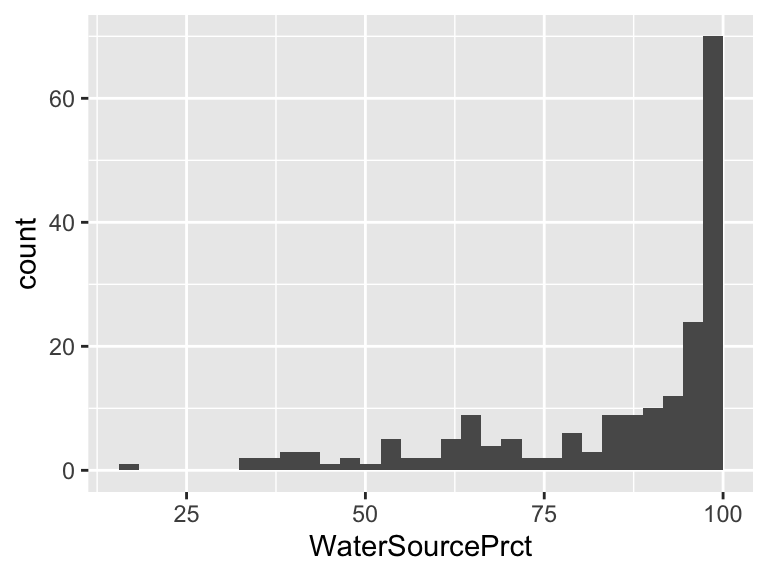

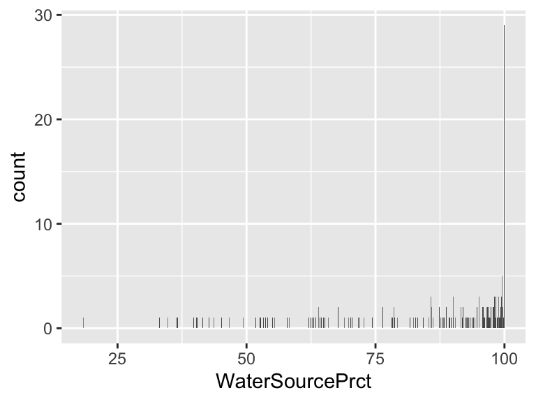

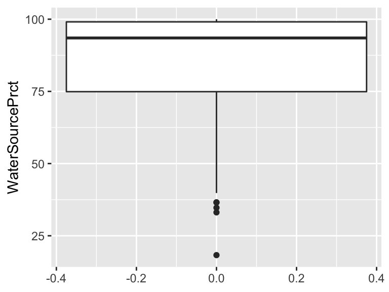

### 4.3.2 Categorical variable for quartiles

```
##  WaterSourcePrct_2011_quart  n   percent
##                          Q1 49 0.2525773
##                          Q2 48 0.2474227
##                          Q3 49 0.2525773
##                          Q4 48 0.2474227
```

# 5 CO2 emissions

```
## [1] 192 216
```

## 5.1 skim

Data summary

| Name | CO2emissions |
| --- | --- |
| Number of rows | 192 |
| Number of columns | 216 |
| _______________________ |  |
| Column type frequency: |  |
| character | 1 |
| numeric | 215 |
| ________________________ |  |
| Group variables | None |

**Variable type: character**

| skim_variable | n_missing | complete_rate | min | max | empty | n_unique | whitespace |
| --- | --- | --- | --- | --- | --- | --- | --- |
| country | 0 | 1 | 3 | 30 | 0 | 192 | 0 |

**Variable type: numeric**

| skim_variable | n_missing | complete_rate | mean | sd | p0 | p25 | p50 | p75 | p100 | hist |
| --- | --- | --- | --- | --- | --- | --- | --- | --- | --- | --- |
| x1800 | 187 | 0.03 | 0.46 | 0.95 | 0.01 | 0.03 | 0.04 | 0.04 | 2.16 | ▇▁▁▁▂ |
| x1801 | 187 | 0.03 | 0.45 | 0.94 | 0.01 | 0.02 | 0.04 | 0.05 | 2.14 | ▇▁▁▁▂ |
| x1802 | 185 | 0.04 | 0.62 | 0.99 | 0.01 | 0.03 | 0.05 | 1.05 | 2.13 | ▇▁▁▁▃ |
| x1803 | 187 | 0.03 | 0.50 | 1.04 | 0.01 | 0.02 | 0.04 | 0.05 | 2.36 | ▇▁▁▁▂ |
| x1804 | 186 | 0.03 | 0.43 | 0.94 | 0.01 | 0.04 | 0.05 | 0.07 | 2.34 | ▇▁▁▁▂ |
| x1805 | 187 | 0.03 | 0.51 | 1.06 | 0.01 | 0.04 | 0.05 | 0.06 | 2.40 | ▇▁▁▁▂ |
| x1806 | 187 | 0.03 | 0.53 | 1.10 | 0.01 | 0.04 | 0.04 | 0.05 | 2.50 | ▇▁▁▁▂ |
| x1807 | 186 | 0.03 | 0.45 | 0.99 | 0.01 | 0.04 | 0.05 | 0.10 | 2.47 | ▇▁▁▁▂ |
| x1808 | 187 | 0.03 | 0.52 | 1.08 | 0.01 | 0.04 | 0.05 | 0.05 | 2.44 | ▇▁▁▁▂ |
| x1809 | 187 | 0.03 | 0.51 | 1.06 | 0.01 | 0.04 | 0.05 | 0.05 | 2.41 | ▇▁▁▁▂ |
| x1810 | 186 | 0.03 | 0.43 | 0.95 | 0.01 | 0.04 | 0.05 | 0.07 | 2.36 | ▇▁▁▁▂ |
| x1811 | 186 | 0.03 | 0.45 | 1.00 | 0.00 | 0.04 | 0.06 | 0.07 | 2.49 | ▇▁▁▁▂ |
| x1812 | 186 | 0.03 | 0.46 | 1.02 | 0.00 | 0.04 | 0.05 | 0.07 | 2.55 | ▇▁▁▁▂ |
| x1813 | 186 | 0.03 | 0.46 | 1.02 | 0.00 | 0.04 | 0.05 | 0.06 | 2.54 | ▇▁▁▁▂ |
| x1814 | 186 | 0.03 | 0.46 | 1.03 | 0.00 | 0.04 | 0.06 | 0.07 | 2.56 | ▇▁▁▁▂ |
| x1815 | 186 | 0.03 | 0.47 | 1.03 | 0.00 | 0.05 | 0.06 | 0.07 | 2.58 | ▇▁▁▁▂ |
| x1816 | 186 | 0.03 | 0.50 | 1.08 | 0.00 | 0.07 | 0.08 | 0.09 | 2.70 | ▇▁▁▁▂ |
| x1817 | 186 | 0.03 | 0.51 | 1.07 | 0.00 | 0.07 | 0.08 | 0.12 | 2.70 | ▇▁▁▁▂ |
| x1818 | 186 | 0.03 | 0.51 | 1.06 | 0.00 | 0.08 | 0.08 | 0.13 | 2.67 | ▇▁▁▁▂ |
| x1819 | 185 | 0.04 | 0.44 | 0.97 | 0.00 | 0.07 | 0.08 | 0.11 | 2.65 | ▇▁▁▁▁ |
| x1820 | 185 | 0.04 | 0.44 | 0.96 | 0.00 | 0.07 | 0.09 | 0.12 | 2.62 | ▇▁▁▁▁ |
| x1821 | 185 | 0.04 | 0.44 | 0.96 | 0.00 | 0.08 | 0.10 | 0.12 | 2.61 | ▇▁▁▁▁ |
| x1822 | 185 | 0.04 | 0.46 | 0.98 | 0.00 | 0.08 | 0.10 | 0.12 | 2.67 | ▇▁▁▁▁ |
| x1823 | 185 | 0.04 | 0.47 | 1.01 | 0.00 | 0.09 | 0.10 | 0.13 | 2.77 | ▇▁▁▁▁ |
| x1824 | 185 | 0.04 | 0.49 | 1.05 | 0.00 | 0.10 | 0.12 | 0.12 | 2.87 | ▇▁▁▁▁ |
| x1825 | 185 | 0.04 | 0.50 | 1.04 | 0.00 | 0.11 | 0.12 | 0.14 | 2.86 | ▇▁▁▁▁ |
| x1826 | 185 | 0.04 | 0.50 | 1.04 | 0.00 | 0.11 | 0.13 | 0.14 | 2.85 | ▇▁▁▁▁ |
| x1827 | 185 | 0.04 | 0.52 | 1.06 | 0.00 | 0.12 | 0.14 | 0.17 | 2.93 | ▇▁▁▁▁ |
| x1828 | 185 | 0.04 | 0.52 | 1.06 | 0.00 | 0.12 | 0.13 | 0.18 | 2.91 | ▇▁▁▁▁ |
| x1829 | 184 | 0.04 | 0.45 | 1.00 | 0.00 | 0.07 | 0.13 | 0.15 | 2.92 | ▇▁▁▁▁ |

[output cut: 185 more lines]

## 5.2 years with fewest missing data

```
## # A tibble: 15 x 2
##    year  n_miss_CO2emissions
##    <chr>               <int>
##  1 x2014                   0
##  2 x2013                   0
##  3 x2012                   0
##  4 x2011                   1
##  5 x2010                   1
##  6 x2009                   1
##  7 x2008                   1
##  8 x2007                   1
##  9 x2006                   2
## 10 x2005                   2
## 11 x2004                   2
## 12 x2003                   2
## 13 x2002                   2
## 14 x2001                   3
## 15 x2000                   3
```

## 5.3 Restrict to 2011

```
## # A tibble: 192 x 2
##    country             CO2emissions
##    <chr>                      <dbl>
##  1 Afghanistan                0.412
##  2 Albania                    1.79
##  3 Algeria                    3.29
##  4 Andorra                    5.87
##  5 Angola                     1.25
##  6 Antigua and Barbuda        5.36
##  7 Argentina                  4.6
##  8 Armenia                    1.71
##  9 Australia                 17.4
## 10 Austria                    7.69
## # … with 182 more rows
```

Data summary

| Name | CO2emissions_11 |
| --- | --- |
| Number of rows | 192 |
| Number of columns | 2 |
| _______________________ |  |
| Column type frequency: |  |
| character | 1 |
| numeric | 1 |
| ________________________ |  |
| Group variables | None |

**Variable type: character**

| skim_variable | n_missing | complete_rate | min | max | empty | n_unique | whitespace |
| --- | --- | --- | --- | --- | --- | --- | --- |
| country | 0 | 1 | 3 | 30 | 0 | 192 | 0 |

**Variable type: numeric**

| skim_variable | n_missing | complete_rate | mean | sd | p0 | p25 | p50 | p75 | p100 | hist |
| --- | --- | --- | --- | --- | --- | --- | --- | --- | --- | --- |
| CO2emissions | 1 | 0.99 | 4.55 | 6.1 | 0.03 | 0.64 | 2.41 | 6.22 | 41.2 | ▇▁▁▁▁ |

# 6 Electricity use

```
## [1] 138  56
```

## 6.1 skim

Data summary

| Name | ElectricityUsePP |
| --- | --- |
| Number of rows | 138 |
| Number of columns | 56 |
| _______________________ |  |
| Column type frequency: |  |
| character | 1 |
| numeric | 55 |
| ________________________ |  |
| Group variables | None |

**Variable type: character**

| skim_variable | n_missing | complete_rate | min | max | empty | n_unique | whitespace |
| --- | --- | --- | --- | --- | --- | --- | --- |
| country | 0 | 1 | 4 | 22 | 0 | 138 | 0 |

**Variable type: numeric**

| skim_variable | n_missing | complete_rate | mean | sd | p0 | p25 | p50 | p75 | p100 | hist |
| --- | --- | --- | --- | --- | --- | --- | --- | --- | --- | --- |
| x1960 | 113 | 0.18 | 2155.37 | 1825.62 | 92.30 | 975.00 | 1590.0 | 2610.0 | 7680 | ▇▅▂▁▁ |
| x1961 | 113 | 0.18 | 2289.60 | 1926.39 | 96.90 | 1050.00 | 1680.0 | 2870.0 | 8400 | ▇▅▂▁▁ |
| x1962 | 113 | 0.18 | 2451.08 | 2093.75 | 112.00 | 1140.00 | 1790.0 | 2900.0 | 9390 | ▇▅▂▁▁ |
| x1963 | 113 | 0.18 | 2650.92 | 2262.62 | 121.00 | 1270.00 | 1920.0 | 3080.0 | 9660 | ▇▅▁▁▁ |
| x1964 | 113 | 0.18 | 2903.40 | 2553.13 | 132.00 | 1350.00 | 2060.0 | 3250.0 | 10600 | ▇▅▁▁▁ |
| x1965 | 112 | 0.19 | 3007.27 | 2685.64 | 144.00 | 1300.00 | 2175.0 | 3465.0 | 11400 | ▇▃▁▁▁ |
| x1966 | 112 | 0.19 | 3160.81 | 2769.95 | 157.00 | 1412.50 | 2280.0 | 3595.0 | 11700 | ▇▃▁▁▁ |
| x1967 | 112 | 0.19 | 3302.08 | 2849.18 | 170.00 | 1532.50 | 2360.0 | 3660.0 | 12300 | ▇▃▁▁▁ |
| x1968 | 112 | 0.19 | 3510.88 | 3004.74 | 185.00 | 1647.50 | 2590.0 | 3827.5 | 13500 | ▇▃▂▁▁ |
| x1969 | 112 | 0.19 | 3776.73 | 3078.41 | 206.00 | 1757.50 | 2825.0 | 4057.5 | 13200 | ▇▇▂▂▁ |
| x1970 | 112 | 0.19 | 4124.08 | 3179.67 | 222.00 | 1875.00 | 3125.0 | 4505.0 | 13500 | ▆▇▂▂▁ |
| x1971 | 29 | 0.79 | 1472.10 | 2402.91 | 6.04 | 127.00 | 459.0 | 1950.0 | 14100 | ▇▁▁▁▁ |
| x1972 | 29 | 0.79 | 1576.05 | 2509.17 | 7.60 | 140.00 | 498.0 | 2020.0 | 14500 | ▇▂▁▁▁ |
| x1973 | 29 | 0.79 | 1689.48 | 2686.84 | 5.80 | 153.00 | 547.0 | 2140.0 | 15500 | ▇▁▁▁▁ |
| x1974 | 29 | 0.79 | 1744.57 | 2794.07 | 7.21 | 166.00 | 572.0 | 2280.0 | 16300 | ▇▁▁▁▁ |
| x1975 | 29 | 0.79 | 1752.66 | 2702.03 | 6.68 | 167.00 | 623.0 | 2480.0 | 16300 | ▇▁▁▁▁ |
| x1976 | 29 | 0.79 | 1874.61 | 2854.61 | 9.03 | 193.00 | 676.0 | 2720.0 | 16900 | ▇▂▁▁▁ |
| x1977 | 29 | 0.79 | 1952.60 | 2884.04 | 9.91 | 204.00 | 722.0 | 2830.0 | 16500 | ▇▂▁▁▁ |
| x1978 | 29 | 0.79 | 2058.00 | 3015.24 | 10.60 | 208.00 | 780.0 | 2980.0 | 17300 | ▇▂▁▁▁ |
| x1979 | 29 | 0.79 | 2200.53 | 3219.84 | 11.70 | 222.00 | 858.0 | 3040.0 | 18900 | ▇▂▁▁▁ |
| x1980 | 29 | 0.79 | 2276.99 | 3285.59 | 12.50 | 252.00 | 867.0 | 3080.0 | 18700 | ▇▂▁▁▁ |
| x1981 | 28 | 0.80 | 2322.39 | 3363.59 | 14.20 | 261.25 | 918.5 | 3040.0 | 19400 | ▇▂▁▁▁ |
| x1982 | 28 | 0.80 | 2380.08 | 3412.51 | 17.60 | 262.00 | 916.5 | 3077.5 | 19400 | ▇▂▁▁▁ |
| x1983 | 28 | 0.80 | 2470.21 | 3557.15 | 18.70 | 256.50 | 950.0 | 3117.5 | 20500 | ▇▂▁▁▁ |
| x1984 | 28 | 0.80 | 2674.77 | 3941.48 | 20.20 | 259.00 | 989.5 | 3297.5 | 21900 | ▇▂▁▁▁ |
| x1985 | 27 | 0.80 | 2756.35 | 4063.35 | 19.80 | 285.50 | 999.0 | 3415.0 | 22600 | ▇▂▁▁▁ |
| x1986 | 27 | 0.80 | 2829.45 | 4109.18 | 19.80 | 281.50 | 1050.0 | 3450.0 | 22200 | ▇▂▁▁▁ |
| x1987 | 27 | 0.80 | 2905.65 | 4146.26 | 20.30 | 304.00 | 1090.0 | 3910.0 | 22800 | ▇▂▁▁▁ |
| x1988 | 27 | 0.80 | 2993.49 | 4279.52 | 19.20 | 317.50 | 1120.0 | 4090.0 | 23000 | ▇▂▁▁▁ |
| x1989 | 27 | 0.80 | 3030.76 | 4301.54 | 18.60 | 327.00 | 1080.0 | 4205.0 | 22900 | ▇▂▁▁▁ |
| x1990 | 7 | 0.95 | 3173.43 | 4031.59 | 22.50 | 435.00 | 1490.0 | 4350.0 | 23400 | ▇▂▁▁▁ |
| x1991 | 6 | 0.96 | 3116.93 | 3983.30 | 21.80 | 413.00 | 1410.0 | 4372.5 | 23800 | ▇▂▁▁▁ |
| x1992 | 6 | 0.96 | 3075.14 | 4064.18 | 21.60 | 440.75 | 1430.0 | 4280.0 | 23800 | ▇▂▁▁▁ |
| x1993 | 6 | 0.96 | 3078.79 | 4209.98 | 23.30 | 490.75 | 1505.0 | 3982.5 | 24000 | ▇▁▁▁▁ |
| x1994 | 6 | 0.96 | 3118.46 | 4241.49 | 18.50 | 513.25 | 1565.0 | 4085.0 | 24200 | ▇▂▁▁▁ |
| x1995 | 4 | 0.97 | 3237.02 | 4372.93 | 13.50 | 499.50 | 1570.0 | 4180.0 | 24500 | ▇▂▁▁▁ |
| x1996 | 4 | 0.97 | 3306.88 | 4395.99 | 20.00 | 530.50 | 1660.0 | 4507.5 | 24000 | ▇▂▁▁▁ |
| x1997 | 4 | 0.97 | 3382.74 | 4503.57 | 23.80 | 561.75 | 1745.0 | 4717.5 | 24300 | ▇▂▁▁▁ |
| x1998 | 4 | 0.97 | 3488.69 | 4682.59 | 23.70 | 573.50 | 1775.0 | 4525.0 | 25400 | ▇▂▁▁▁ |
| x1999 | 4 | 0.97 | 3547.58 | 4770.90 | 22.90 | 582.75 | 1775.0 | 4730.0 | 25100 | ▇▂▁▁▁ |
| x2000 | 2 | 0.99 | 3601.03 | 4837.07 | 22.60 | 568.00 | 1765.0 | 4682.5 | 26200 | ▇▂▁▁▁ |
| x2001 | 2 | 0.99 | 3656.68 | 4905.29 | 26.40 | 589.25 | 1780.0 | 4797.5 | 27000 | ▇▂▁▁▁ |
| x2002 | 2 | 0.99 | 3726.75 | 4955.11 | 26.10 | 610.00 | 1800.0 | 4945.0 | 27900 | ▇▂▁▁▁ |
| x2003 | 2 | 0.99 | 3802.28 | 4945.06 | 28.50 | 635.50 | 1880.0 | 5107.5 | 27700 | ▇▂▁▁▁ |
| x2004 | 2 | 0.99 | 3865.85 | 4988.37 | 28.10 | 659.00 | 1940.0 | 5257.5 | 28200 | ▇▂▁▁▁ |
| x2005 | 1 | 0.99 | 3944.50 | 5024.11 | 33.40 | 681.00 | 2050.0 | 5530.0 | 28000 | ▇▂▁▁▁ |
| x2006 | 1 | 0.99 | 4040.18 | 5159.54 | 34.90 | 693.00 | 2170.0 | 5830.0 | 31300 | ▇▂▁▁▁ |
| x2007 | 1 | 0.99 | 4118.45 | 5383.39 | 25.30 | 716.00 | 2160.0 | 5800.0 | 36900 | ▇▁▁▁▁ |
| x2008 | 1 | 0.99 | 4196.40 | 5961.58 | 23.60 | 732.00 | 2220.0 | 5810.0 | 50100 | ▇▁▁▁▁ |
| x2009 | 1 | 0.99 | 4069.45 | 5878.03 | 35.70 | 727.00 | 2190.0 | 5630.0 | 51300 | ▇▁▁▁▁ |
| x2010 | 1 | 0.99 | 4233.43 | 6010.43 | 24.40 | 742.00 | 2360.0 | 5520.0 | 51400 | ▇▁▁▁▁ |
| x2011 | 1 | 0.99 | 4220.92 | 5964.07 | 31.10 | 699.00 | 2410.0 | 5600.0 | 52400 | ▇▁▁▁▁ |
| x2012 | 1 | 0.99 | 4252.11 | 6020.63 | 38.70 | 732.00 | 2430.0 | 5530.0 | 53200 | ▇▁▁▁▁ |
| x2013 | 1 | 0.99 | 4260.13 | 6084.10 | 39.80 | 773.00 | 2510.0 | 5410.0 | 54800 | ▇▁▁▁▁ |
| x2014 | 1 | 0.99 | 4253.62 | 6024.00 | 39.00 | 812.00 | 2580.0 | 5360.0 | 53800 | ▇▁▁▁▁ |

## 6.2 years with fewest missing data

```
## # A tibble: 15 x 2
##    year  n_miss_ElectricityUsePP
##    <chr>                   <int>
##  1 x2014                       1
##  2 x2013                       1
##  3 x2012                       1
##  4 x2011                       1
##  5 x2010                       1
##  6 x2009                       1
##  7 x2008                       1
##  8 x2007                       1
##  9 x2006                       1
## 10 x2005                       1
## 11 x2004                       2
## 12 x2003                       2
## 13 x2002                       2
## 14 x2001                       2
## 15 x2000                       2
```

## 6.3 Restrict to 2011

```
## # A tibble: 138 x 2
##    country    ElectricityUsePP
##    <chr>                 <dbl>
##  1 Albania                2210
##  2 Algeria                1120
##  3 Angola                  207
##  4 Argentina              2900
##  5 Armenia                1810
##  6 Australia             10600
##  7 Austria                8430
##  8 Azerbaijan             1710
##  9 Bahrain               17900
## 10 Bangladesh              258
## # … with 128 more rows
```

Data summary

| Name | ElectricityUsePP_11 |
| --- | --- |
| Number of rows | 138 |
| Number of columns | 2 |
| _______________________ |  |
| Column type frequency: |  |
| character | 1 |
| numeric | 1 |
| ________________________ |  |
| Group variables | None |

**Variable type: character**

| skim_variable | n_missing | complete_rate | min | max | empty | n_unique | whitespace |
| --- | --- | --- | --- | --- | --- | --- | --- |
| country | 0 | 1 | 4 | 22 | 0 | 138 | 0 |

**Variable type: numeric**

[output not shown]

food_supply_kilocalories_per_person_and_day

```
## [1] 168  54
```

## 6.4 skim

Data summary

| Name | FoodSupplykcPPD |
| --- | --- |
| Number of rows | 168 |
| Number of columns | 54 |
| _______________________ |  |
| Column type frequency: |  |
| character | 1 |
| numeric | 53 |
| ________________________ |  |
| Group variables | None |

**Variable type: character**

| skim_variable | n_missing | complete_rate | min | max | empty | n_unique | whitespace |
| --- | --- | --- | --- | --- | --- | --- | --- |
| country | 0 | 1 | 3 | 30 | 0 | 168 | 0 |

**Variable type: numeric**

| skim_variable | n_missing | complete_rate | mean | sd | p0 | p25 | p50 | p75 | p100 | hist |
| --- | --- | --- | --- | --- | --- | --- | --- | --- | --- | --- |
| x1961 | 27 | 0.84 | 2229.93 | 490.88 | 1330 | 1880.0 | 2120 | 2500.0 | 3580 | ▃▇▃▂▂ |
| x1962 | 27 | 0.84 | 2252.70 | 481.53 | 1310 | 1910.0 | 2150 | 2550.0 | 3480 | ▂▇▅▂▂ |
| x1963 | 27 | 0.84 | 2261.21 | 477.30 | 1450 | 1940.0 | 2150 | 2630.0 | 3410 | ▃▇▃▃▂ |
| x1964 | 27 | 0.84 | 2289.08 | 472.68 | 1540 | 1940.0 | 2170 | 2580.0 | 3450 | ▅▇▃▂▂ |
| x1965 | 27 | 0.84 | 2310.71 | 474.61 | 1550 | 1940.0 | 2230 | 2590.0 | 3450 | ▅▇▃▃▂ |
| x1966 | 27 | 0.84 | 2320.78 | 477.57 | 1450 | 1980.0 | 2220 | 2640.0 | 3490 | ▃▇▃▂▂ |
| x1967 | 27 | 0.84 | 2333.76 | 473.59 | 1450 | 1990.0 | 2240 | 2660.0 | 3450 | ▃▇▅▃▂ |
| x1968 | 27 | 0.84 | 2351.91 | 477.72 | 1460 | 2010.0 | 2240 | 2670.0 | 3450 | ▂▇▅▃▂ |
| x1969 | 27 | 0.84 | 2367.38 | 482.21 | 1440 | 2010.0 | 2250 | 2650.0 | 3470 | ▂▇▅▃▂ |
| x1970 | 27 | 0.84 | 2382.77 | 483.45 | 1460 | 2030.0 | 2270 | 2690.0 | 3500 | ▂▇▅▂▂ |
| x1971 | 27 | 0.84 | 2392.70 | 487.78 | 1480 | 2030.0 | 2270 | 2740.0 | 3520 | ▂▇▅▃▂ |
| x1972 | 27 | 0.84 | 2377.66 | 497.84 | 1440 | 2000.0 | 2260 | 2720.0 | 3520 | ▂▇▅▃▂ |
| x1973 | 27 | 0.84 | 2392.70 | 505.52 | 1430 | 2000.0 | 2280 | 2740.0 | 3570 | ▂▇▅▃▂ |
| x1974 | 27 | 0.84 | 2398.16 | 499.60 | 1460 | 2000.0 | 2320 | 2740.0 | 3520 | ▂▇▆▃▂ |
| x1975 | 27 | 0.84 | 2397.80 | 497.83 | 1480 | 2030.0 | 2310 | 2720.0 | 3540 | ▃▇▆▃▃ |
| x1976 | 27 | 0.84 | 2425.60 | 506.99 | 1490 | 2050.0 | 2310 | 2770.0 | 3590 | ▃▇▆▃▃ |
| x1977 | 27 | 0.84 | 2435.82 | 496.49 | 1400 | 2100.0 | 2350 | 2740.0 | 3580 | ▃▇▇▅▃ |
| x1978 | 27 | 0.84 | 2464.96 | 495.65 | 1440 | 2120.0 | 2360 | 2810.0 | 3590 | ▂▇▇▃▃ |
| x1979 | 27 | 0.84 | 2483.76 | 492.97 | 1370 | 2130.0 | 2370 | 2820.0 | 3610 | ▂▇▇▅▃ |
| x1980 | 27 | 0.84 | 2507.59 | 504.46 | 1440 | 2130.0 | 2400 | 2890.0 | 3600 | ▂▇▅▅▂ |
| x1981 | 27 | 0.84 | 2513.83 | 495.27 | 1450 | 2170.0 | 2440 | 2900.0 | 3660 | ▂▇▅▅▂ |
| x1982 | 27 | 0.84 | 2512.20 | 497.51 | 1490 | 2160.0 | 2420 | 2930.0 | 3640 | ▂▇▃▅▂ |
| x1983 | 27 | 0.84 | 2513.12 | 497.85 | 1530 | 2140.0 | 2440 | 2950.0 | 3610 | ▃▇▆▅▂ |
| x1984 | 27 | 0.84 | 2527.73 | 503.74 | 1520 | 2130.0 | 2450 | 2990.0 | 3650 | ▃▇▇▆▂ |
| x1985 | 27 | 0.84 | 2547.09 | 498.60 | 1560 | 2120.0 | 2470 | 2930.0 | 3630 | ▃▇▇▅▃ |
| x1986 | 27 | 0.84 | 2553.55 | 501.82 | 1600 | 2160.0 | 2480 | 2970.0 | 3660 | ▃▇▆▅▃ |
| x1987 | 27 | 0.84 | 2564.11 | 520.88 | 1560 | 2160.0 | 2500 | 2950.0 | 3690 | ▂▇▇▅▃ |
| x1988 | 27 | 0.84 | 2573.62 | 515.89 | 1580 | 2190.0 | 2510 | 3010.0 | 3720 | ▃▇▆▅▃ |
| x1989 | 27 | 0.84 | 2572.84 | 518.78 | 1470 | 2180.0 | 2490 | 2990.0 | 3720 | ▁▇▆▅▂ |
| x1990 | 26 | 0.85 | 2548.94 | 510.04 | 1610 | 2190.0 | 2460 | 2960.0 | 3780 | ▃▇▅▅▂ |
| x1991 | 26 | 0.85 | 2547.32 | 502.95 | 1510 | 2190.0 | 2445 | 2937.5 | 3720 | ▂▇▅▃▂ |
| x1992 | 7 | 0.96 | 2561.86 | 501.18 | 1510 | 2180.0 | 2500 | 2940.0 | 3710 | ▂▇▇▅▂ |
| x1993 | 4 | 0.98 | 2554.88 | 500.04 | 1510 | 2182.5 | 2465 | 2935.0 | 3730 | ▂▇▇▅▂ |
| x1994 | 4 | 0.98 | 2569.21 | 490.21 | 1550 | 2225.0 | 2505 | 2930.0 | 3730 | ▂▇▆▅▂ |
| x1995 | 4 | 0.98 | 2581.04 | 486.77 | 1570 | 2200.0 | 2545 | 2920.0 | 3720 | ▂▇▆▅▂ |
| x1996 | 4 | 0.98 | 2596.40 | 495.32 | 1660 | 2205.0 | 2555 | 2967.5 | 3690 | ▆▇▇▆▃ |
| x1997 | 4 | 0.98 | 2607.50 | 496.88 | 1680 | 2170.0 | 2600 | 2972.5 | 3680 | ▅▇▇▅▃ |
| x1998 | 4 | 0.98 | 2620.55 | 498.59 | 1680 | 2167.5 | 2605 | 2962.5 | 3680 | ▅▇▇▃▅ |
| x1999 | 4 | 0.98 | 2637.38 | 497.16 | 1730 | 2207.5 | 2635 | 2985.0 | 3700 | ▅▇▇▃▃ |
| x2000 | 2 | 0.99 | 2658.92 | 499.53 | 1790 | 2250.0 | 2610 | 3047.5 | 3760 | ▆▇▇▆▃ |
| x2001 | 2 | 0.99 | 2678.92 | 499.10 | 1740 | 2280.0 | 2635 | 3050.0 | 3750 | ▃▇▇▅▃ |
| x2002 | 2 | 0.99 | 2693.92 | 492.56 | 1830 | 2290.0 | 2675 | 3037.5 | 3780 | ▆▇▇▅▃ |
| x2003 | 2 | 0.99 | 2703.31 | 485.28 | 1870 | 2312.5 | 2690 | 3060.0 | 3780 | ▇▇▇▆▃ |
| x2004 | 2 | 0.99 | 2725.30 | 484.38 | 1870 | 2342.5 | 2685 | 3097.5 | 3810 | ▆▇▇▆▃ |
| x2005 | 2 | 0.99 | 2742.11 | 474.32 | 1870 | 2352.5 | 2725 | 3107.5 | 3830 | ▅▇▇▅▃ |
| x2006 | 0 | 1.00 | 2760.60 | 469.73 | 1840 | 2377.5 | 2770 | 3122.5 | 3780 | ▃▇▇▆▃ |
| x2007 | 0 | 1.00 | 2780.65 | 465.19 | 1780 | 2410.0 | 2780 | 3160.0 | 3760 | ▃▇▇▆▅ |
| x2008 | 0 | 1.00 | 2790.12 | 460.56 | 1800 | 2437.5 | 2780 | 3160.0 | 3720 | ▃▇▇▇▅ |
| x2009 | 0 | 1.00 | 2798.63 | 450.61 | 1880 | 2450.0 | 2760 | 3142.5 | 3720 | ▃▇▇▇▅ |
| x2010 | 0 | 1.00 | 2810.12 | 442.63 | 1900 | 2470.0 | 2795 | 3152.5 | 3720 | ▃▇▇▆▃ |
| x2011 | 0 | 1.00 | 2825.06 | 443.59 | 1910 | 2490.0 | 2775 | 3172.5 | 3740 | ▅▇▇▇▅ |
| x2012 | 0 | 1.00 | 2831.96 | 440.38 | 1920 | 2487.5 | 2780 | 3182.5 | 3740 | ▃▇▇▆▅ |
| x2013 | 0 | 1.00 | 2845.95 | 444.20 | 1880 | 2505.0 | 2825 | 3200.0 | 3770 | ▃▇▇▇▃ |

## 6.5 years with fewest missing data

```
## # A tibble: 15 x 2
##    year  n_miss_FoodSupplykcPPD
##    <chr>                  <int>
##  1 x2013                      0
##  2 x2012                      0
##  3 x2011                      0
##  4 x2010                      0
##  5 x2009                      0
##  6 x2008                      0
##  7 x2007                      0
##  8 x2006                      0
##  9 x2005                      2
## 10 x2004                      2
## 11 x2003                      2
## 12 x2002                      2
## 13 x2001                      2
## 14 x2000                      2
## 15 x1999                      4
```

## 6.6 Restrict to 2011

```
## # A tibble: 168 x 2
##    country             FoodSupplykcPPD
##    <chr>                         <dbl>
##  1 Afghanistan                    2110
##  2 Albania                        3130
##  3 Algeria                        3220
##  4 Angola                         2410
##  5 Antigua and Barbuda            2370
##  6 Argentina                      3160
##  7 Armenia                        2790
##  8 Australia                      3240
##  9 Austria                        3740
## 10 Azerbaijan                     3040
## # … with 158 more rows
```

Data summary

| Name | FoodSupplykcPPD_11 |
| --- | --- |
| Number of rows | 168 |
| Number of columns | 2 |
| _______________________ |  |
| Column type frequency: |  |
| character | 1 |
| numeric | 1 |
| ________________________ |  |
| Group variables | None |

**Variable type: character**

| skim_variable | n_missing | complete_rate | min | max | empty | n_unique | whitespace |
| --- | --- | --- | --- | --- | --- | --- | --- |
| country | 0 | 1 | 3 | 30 | 0 | 168 | 0 |

**Variable type: numeric**

| skim_variable | n_missing | complete_rate | mean | sd | p0 | p25 | p50 | p75 | p100 | hist |
| --- | --- | --- | --- | --- | --- | --- | --- | --- | --- | --- |
| FoodSupplykcPPD | 0 | 1 | 2825.06 | 443.59 | 1910 | 2490 | 2775 | 3172.5 | 3740 | ▅▇▇▇▅ |

# 7 Income

income_per_person_gdppercapita_ppp_inflation_adjusted

```
## [1] 193 242
```

```
## [1] "x2035" "x2036" "x2037" "x2038" "x2039" "x2040"
```

```
## [1] 193 221
```

## 7.1 skim

Data summary

| Name | IncomePP |
| --- | --- |
| Number of rows | 193 |
| Number of columns | 221 |
| _______________________ |  |
| Column type frequency: |  |
| character | 1 |
| numeric | 220 |
| ________________________ |  |
| Group variables | None |

**Variable type: character**

| skim_variable | n_missing | complete_rate | min | max | empty | n_unique | whitespace |
| --- | --- | --- | --- | --- | --- | --- | --- |
| country | 0 | 1 | 3 | 30 | 0 | 193 | 0 |

**Variable type: numeric**

| skim_variable | n_missing | complete_rate | mean | sd | p0 | p25 | p50 | p75 | p100 | hist |
| --- | --- | --- | --- | --- | --- | --- | --- | --- | --- | --- |
| x1800 | 0 | 1 | 947.78 | 508.35 | 350 | 608 | 847 | 1100 | 4230 | ▇▂▁▁▁ |
| x1801 | 0 | 1 | 948.27 | 506.75 | 350 | 608 | 847 | 1100 | 4160 | ▇▂▁▁▁ |
| x1802 | 0 | 1 | 951.22 | 516.69 | 350 | 608 | 847 | 1110 | 4390 | ▇▂▁▁▁ |
| x1803 | 0 | 1 | 950.91 | 511.55 | 350 | 609 | 847 | 1110 | 4300 | ▇▂▁▁▁ |
| x1804 | 0 | 1 | 952.77 | 518.97 | 350 | 609 | 848 | 1110 | 4500 | ▇▂▁▁▁ |
| x1805 | 0 | 1 | 953.20 | 513.49 | 350 | 609 | 848 | 1120 | 4240 | ▇▂▁▁▁ |
| x1806 | 0 | 1 | 954.31 | 514.67 | 350 | 610 | 849 | 1120 | 4270 | ▇▂▁▁▁ |
| x1807 | 0 | 1 | 953.98 | 508.13 | 350 | 610 | 850 | 1130 | 3910 | ▇▂▁▁▁ |
| x1808 | 0 | 1 | 950.91 | 490.32 | 350 | 610 | 850 | 1130 | 3480 | ▇▃▁▁▁ |
| x1809 | 0 | 1 | 952.20 | 492.60 | 350 | 611 | 851 | 1140 | 3430 | ▇▃▁▁▁ |
| x1810 | 0 | 1 | 956.37 | 509.74 | 350 | 611 | 852 | 1140 | 3930 | ▇▂▁▁▁ |
| x1811 | 0 | 1 | 957.24 | 508.96 | 350 | 611 | 852 | 1140 | 3960 | ▇▂▁▁▁ |
| x1812 | 0 | 1 | 954.04 | 489.70 | 351 | 612 | 853 | 1150 | 3450 | ▇▃▁▁▁ |
| x1813 | 0 | 1 | 954.25 | 486.17 | 351 | 612 | 855 | 1150 | 3420 | ▇▃▁▁▁ |
| x1814 | 0 | 1 | 954.37 | 481.88 | 351 | 612 | 855 | 1160 | 3290 | ▇▅▁▁▁ |
| x1815 | 0 | 1 | 961.34 | 513.66 | 351 | 613 | 855 | 1160 | 3940 | ▇▂▁▁▁ |
| x1816 | 0 | 1 | 959.26 | 500.13 | 351 | 613 | 855 | 1170 | 3750 | ▇▃▁▁▁ |
| x1817 | 0 | 1 | 960.32 | 502.03 | 351 | 613 | 856 | 1170 | 3780 | ▇▃▁▁▁ |
| x1818 | 0 | 1 | 962.17 | 505.32 | 351 | 614 | 856 | 1170 | 3830 | ▇▃▁▁▁ |
| x1819 | 0 | 1 | 961.26 | 497.29 | 351 | 614 | 856 | 1170 | 3640 | ▇▃▁▁▁ |
| x1820 | 0 | 1 | 964.61 | 510.44 | 351 | 614 | 857 | 1170 | 3900 | ▇▂▁▁▁ |
| x1821 | 0 | 1 | 971.28 | 514.09 | 351 | 618 | 862 | 1180 | 3810 | ▇▃▁▁▁ |
| x1822 | 0 | 1 | 975.25 | 516.65 | 351 | 622 | 871 | 1180 | 3840 | ▇▃▁▁▁ |
| x1823 | 0 | 1 | 981.10 | 525.47 | 351 | 625 | 875 | 1190 | 4030 | ▇▂▁▁▁ |
| x1824 | 0 | 1 | 987.64 | 532.88 | 351 | 629 | 881 | 1200 | 3990 | ▇▃▁▁▁ |
| x1825 | 0 | 1 | 992.68 | 533.12 | 351 | 633 | 883 | 1210 | 3880 | ▇▃▁▁▁ |
| x1826 | 0 | 1 | 997.24 | 533.72 | 351 | 636 | 887 | 1210 | 3940 | ▇▃▁▁▁ |
| x1827 | 0 | 1 | 1004.26 | 547.74 | 351 | 640 | 894 | 1210 | 4160 | ▇▂▁▁▁ |
| x1828 | 0 | 1 | 1009.11 | 551.27 | 351 | 641 | 896 | 1220 | 4240 | ▇▂▁▁▁ |
| x1829 | 0 | 1 | 1014.15 | 553.08 | 351 | 643 | 897 | 1220 | 4240 | ▇▂▁▁▁ |

[output cut: 190 more lines]

## 7.2 years with fewest missing data

```
## # A tibble: 15 x 2
##    year  n_miss_IncomePP
##    <chr>           <int>
##  1 x2019               0
##  2 x2018               0
##  3 x2017               0
##  4 x2016               0
##  5 x2015               0
##  6 x2014               0
##  7 x2013               0
##  8 x2012               0
##  9 x2011               0
## 10 x2010               0
## 11 x2009               0
## 12 x2008               0
## 13 x2007               0
## 14 x2006               0
## 15 x2005               0
```

## 7.3 Restrict to 2011

```
## # A tibble: 193 x 2
##    country             IncomePP
##    <chr>                  <dbl>
##  1 Afghanistan             1660
##  2 Albania                10200
##  3 Algeria                13000
##  4 Andorra                42000
##  5 Angola                  5910
##  6 Antigua and Barbuda    18600
##  7 Argentina              19600
##  8 Armenia                 7020
##  9 Australia              41800
## 10 Austria                44200
## # … with 183 more rows
```

Data summary

| Name | IncomePP_11 |
| --- | --- |
| Number of rows | 193 |
| Number of columns | 2 |
| _______________________ |  |
| Column type frequency: |  |
| character | 1 |
| numeric | 1 |
| ________________________ |  |
| Group variables | None |

**Variable type: character**

| skim_variable | n_missing | complete_rate | min | max | empty | n_unique | whitespace |
| --- | --- | --- | --- | --- | --- | --- | --- |
| country | 0 | 1 | 3 | 30 | 0 | 193 | 0 |

**Variable type: numeric**

| skim_variable | n_missing | complete_rate | mean | sd | p0 | p25 | p50 | p75 | p100 | hist |
| --- | --- | --- | --- | --- | --- | --- | --- | --- | --- | --- |
| IncomePP | 0 | 1 | 16704.45 | 19098.61 | 614 | 3370 | 10100 | 22700 | 129000 | ▇▂▁▁▁ |

# 8 Population

population_total.csv

```
## [1] 195 302
```

```
## [1] "x2095" "x2096" "x2097" "x2098" "x2099" "x2100"
```

```
## [1] 195 221
```

## 8.1 skim

Data summary

| Name | population |
| --- | --- |
| Number of rows | 195 |
| Number of columns | 221 |
| _______________________ |  |
| Column type frequency: |  |
| character | 1 |
| numeric | 220 |
| ________________________ |  |
| Group variables | None |

**Variable type: character**

| skim_variable | n_missing | complete_rate | min | max | empty | n_unique | whitespace |
| --- | --- | --- | --- | --- | --- | --- | --- |
| country | 0 | 1 | 3 | 30 | 0 | 195 | 0 |

**Variable type: numeric**

| skim_variable | n_missing | complete_rate | mean | sd | p0 | p25 | p50 | p75 | p100 | hist |
| --- | --- | --- | --- | --- | --- | --- | --- | --- | --- | --- |
| x1800 | 0 | 1 | 4858439 | 26232976 | 905 | 112000 | 713000 | 2120000 | 3.22e+08 | ▇▁▁▁▁ |
| x1801 | 0 | 1 | 4875184 | 26359250 | 905 | 112000 | 713000 | 2120000 | 3.24e+08 | ▇▁▁▁▁ |
| x1802 | 0 | 1 | 4896420 | 26548602 | 905 | 112000 | 713000 | 2120000 | 3.27e+08 | ▇▁▁▁▁ |
| x1803 | 0 | 1 | 4921854 | 26769261 | 905 | 112000 | 713000 | 2120000 | 3.30e+08 | ▇▁▁▁▁ |
| x1804 | 0 | 1 | 4944249 | 26959289 | 905 | 112000 | 713000 | 2120000 | 3.33e+08 | ▇▁▁▁▁ |
| x1805 | 0 | 1 | 4965603 | 27149562 | 905 | 112000 | 713000 | 2120000 | 3.36e+08 | ▇▁▁▁▁ |
| x1806 | 0 | 1 | 4987121 | 27308236 | 905 | 112000 | 713000 | 2120000 | 3.38e+08 | ▇▁▁▁▁ |
| x1807 | 0 | 1 | 5008500 | 27498553 | 905 | 112000 | 713000 | 2120000 | 3.41e+08 | ▇▁▁▁▁ |
| x1808 | 0 | 1 | 5029397 | 27689430 | 905 | 112000 | 713000 | 2120000 | 3.44e+08 | ▇▁▁▁▁ |
| x1809 | 0 | 1 | 5056351 | 27911492 | 905 | 112000 | 717000 | 2120000 | 3.47e+08 | ▇▁▁▁▁ |
| x1810 | 0 | 1 | 5083941 | 28166153 | 905 | 112000 | 718000 | 2120000 | 3.51e+08 | ▇▁▁▁▁ |
| x1811 | 0 | 1 | 5101684 | 28295205 | 905 | 112000 | 719000 | 2120000 | 3.53e+08 | ▇▁▁▁▁ |
| x1812 | 0 | 1 | 5128208 | 28516995 | 905 | 112000 | 720000 | 2125000 | 3.56e+08 | ▇▁▁▁▁ |
| x1813 | 0 | 1 | 5152721 | 28710546 | 905 | 112000 | 722000 | 2130000 | 3.59e+08 | ▇▁▁▁▁ |
| x1814 | 0 | 1 | 5177047 | 28903306 | 905 | 112500 | 725000 | 2135000 | 3.62e+08 | ▇▁▁▁▁ |
| x1815 | 0 | 1 | 5206732 | 29126872 | 905 | 112500 | 728000 | 2145000 | 3.65e+08 | ▇▁▁▁▁ |
| x1816 | 0 | 1 | 5233215 | 29321050 | 905 | 112500 | 729000 | 2150000 | 3.68e+08 | ▇▁▁▁▁ |
| x1817 | 0 | 1 | 5264645 | 29544887 | 905 | 112500 | 732000 | 2155000 | 3.71e+08 | ▇▁▁▁▁ |
| x1818 | 0 | 1 | 5290553 | 29739282 | 905 | 113000 | 734000 | 2160000 | 3.74e+08 | ▇▁▁▁▁ |
| x1819 | 0 | 1 | 5322297 | 29963475 | 905 | 113000 | 737000 | 2170000 | 3.77e+08 | ▇▁▁▁▁ |
| x1820 | 0 | 1 | 5349691 | 30158394 | 905 | 113000 | 737000 | 2175000 | 3.80e+08 | ▇▁▁▁▁ |
| x1821 | 0 | 1 | 5384081 | 30383189 | 905 | 113500 | 737000 | 2185000 | 3.83e+08 | ▇▁▁▁▁ |
| x1822 | 0 | 1 | 5414536 | 30579997 | 905 | 113500 | 738000 | 2190000 | 3.86e+08 | ▇▁▁▁▁ |
| x1823 | 0 | 1 | 5443455 | 30740500 | 905 | 114000 | 742000 | 2195000 | 3.88e+08 | ▇▁▁▁▁ |
| x1824 | 0 | 1 | 5475105 | 30937245 | 905 | 114000 | 747000 | 2205000 | 3.91e+08 | ▇▁▁▁▁ |
| x1825 | 0 | 1 | 5504670 | 31098174 | 905 | 114500 | 747000 | 2220000 | 3.93e+08 | ▇▁▁▁▁ |
| x1826 | 0 | 1 | 5535756 | 31259130 | 905 | 115500 | 747000 | 2235000 | 3.95e+08 | ▇▁▁▁▁ |
| x1827 | 0 | 1 | 5563416 | 31392427 | 905 | 116500 | 747000 | 2245000 | 3.97e+08 | ▇▁▁▁▁ |
| x1828 | 0 | 1 | 5597358 | 31554524 | 905 | 118000 | 747000 | 2260000 | 3.99e+08 | ▇▁▁▁▁ |
| x1829 | 0 | 1 | 5631303 | 31716068 | 905 | 119000 | 754000 | 2275000 | 4.01e+08 | ▇▁▁▁▁ |

[output cut: 190 more lines]

## 8.2 years with fewest missing data

```
## # A tibble: 15 x 2
##    year  n_miss_population
##    <chr>             <int>
##  1 x2019                 0
##  2 x2018                 0
##  3 x2017                 0
##  4 x2016                 0
##  5 x2015                 0
##  6 x2014                 0
##  7 x2013                 0
##  8 x2012                 0
##  9 x2011                 0
## 10 x2010                 0
## 11 x2009                 0
## 12 x2008                 0
## 13 x2007                 0
## 14 x2006                 0
## 15 x2005                 0
```

## 8.3 Restrict to 2011

```
## # A tibble: 195 x 2
##    country             population
##    <chr>                    <dbl>
##  1 Afghanistan           29700000
##  2 Albania                2930000
##  3 Algeria               36800000
##  4 Andorra                  83800
##  5 Angola                24200000
##  6 Antigua and Barbuda      95700
##  7 Argentina             41700000
##  8 Armenia                2880000
##  9 Australia             22500000
## 10 Austria                8460000
## # … with 185 more rows
```

Data summary

| Name | population_11 |
| --- | --- |
| Number of rows | 195 |
| Number of columns | 2 |
| _______________________ |  |
| Column type frequency: |  |
| character | 1 |
| numeric | 1 |
| ________________________ |  |
| Group variables | None |

**Variable type: character**

| skim_variable | n_missing | complete_rate | min | max | empty | n_unique | whitespace |
| --- | --- | --- | --- | --- | --- | --- | --- |
| country | 0 | 1 | 3 | 30 | 0 | 195 | 0 |

**Variable type: numeric**

| skim_variable | n_missing | complete_rate | mean | sd | p0 | p25 | p50 | p75 | p100 | hist |
| --- | --- | --- | --- | --- | --- | --- | --- | --- | --- | --- |
| population | 0 | 1 | 35947595 | 136870900 | 796 | 1725000 | 7570000 | 24500000 | 1.37e+09 | ▇▁▁▁▁ |

# 9 Compare years with fewest missing values

Looks like 2011 is the most recent year with the fewest missing values

```
##                       ls()
## 1       CO2emissions_minNA
## 2   ElectricityUsePP_minNA
## 3 FemaleLiteracyRate_minNA
## 4    FoodSupplykcPPD_minNA
## 5           IncomePP_minNA
## 6  LifeExpectancyYrs_minNA
## 7         population_minNA
## 8    WaterSourcePrct_minNA
```

```
## [1] 220   9
```

```
## # A tibble: 220 x 9
##    year  n_miss_CO2emiss… n_miss_Electric… n_miss_FoodSupp… n_miss_IncomePP
##    <chr>            <int>            <int>            <int>           <int>
##  1 x2014                0                1               NA               0
##  2 x2013                0                1                0               0
##  3 x2012                0                1                0               0
##  4 x2011                1                1                0               0
##  5 x2010                1                1                0               0
##  6 x2009                1                1                0               0
##  7 x2008                1                1                0               0
##  8 x2007                1                1                0               0
##  9 x2006                2                1                0               0
## 10 x2005                2                1                2               0
## # … with 210 more rows, and 4 more variables:
## #   n_miss_LifeExpectancyYrs <int>, n_miss_FemaleLiteracyRate <int>,
## #   n_miss_population <int>, n_miss_WaterSourcePrct <int>
```

| year | n_miss_CO2emissions | n_miss_ElectricityUsePP | n_miss_FoodSupplykcPPD | n_miss_IncomePP | n_miss_LifeExpectancyYrs | n_miss_FemaleLiteracyRate | n_miss_population | n_miss_WaterSourcePrct |
| --- | --- | --- | --- | --- | --- | --- | --- | --- |
| x2011 | 1 | 1 | 0 | 0 | 0 | 70 | 0 | 0 |
| x2010 | 1 | 1 | 0 | 0 | 0 | 116 | 0 | 1 |
| x2009 | 1 | 1 | 0 | 0 | 0 | 122 | 0 | 2 |
| x2008 | 1 | 1 | 0 | 0 | 0 | 123 | 0 | 2 |
| x2007 | 1 | 1 | 0 | 0 | 0 | 119 | 0 | 2 |
| x2006 | 2 | 1 | 0 | 0 | 0 | 126 | 0 | 3 |
| x2005 | 2 | 1 | 2 | 0 | 0 | 131 | 0 | 4 |
| x2004 | 2 | 2 | 2 | 0 | 0 | 121 | 0 | 6 |
| x2003 | 2 | 2 | 2 | 0 | 0 | 140 | 0 | 6 |
| x2002 | 2 | 2 | 2 | 0 | 0 | 131 | 0 | 6 |
| x2001 | 3 | 2 | 2 | 0 | 0 | 121 | 0 | 8 |
| x2000 | 3 | 2 | 2 | 0 | 0 | 108 | 0 | 11 |

# 10 Joins

## 10.1 Life expectancy & Adult female FemaleLiteracyRate rate

```
## # A tibble: 188 x 3
##    country             LifeExpectancyYrs FemaleLiteracyRate
##    <chr>                           <dbl>              <dbl>
##  1 Afghanistan                      56.7               13
##  2 Albania                          76.7               95.7
##  3 Algeria                          76.7               NA
##  4 Andorra                          82.6               NA
##  5 Angola                           60.9               58.6
##  6 Antigua and Barbuda              76.9               99.4
##  7 Argentina                        76                 97.9
##  8 Armenia                          73.8               99.5
##  9 Australia                        82.2               NA
## 10 Austria                          80.7               NA
## # … with 178 more rows
```

Data summary

| Name | LifeExpectancyYrs_FemaleL… |
| --- | --- |
| Number of rows | 188 |
| Number of columns | 3 |
| _______________________ |  |
| Column type frequency: |  |
| character | 1 |
| numeric | 2 |
| ________________________ |  |
| Group variables | None |

**Variable type: character**

| skim_variable | n_missing | complete_rate | min | max | empty | n_unique | whitespace |
| --- | --- | --- | --- | --- | --- | --- | --- |
| country | 0 | 1 | 3 | 30 | 0 | 188 | 0 |

**Variable type: numeric**

| skim_variable | n_missing | complete_rate | mean | sd | p0 | p25 | p50 | p75 | p100 | hist |
| --- | --- | --- | --- | --- | --- | --- | --- | --- | --- | --- |
| LifeExpectancyYrs | 1 | 0.99 | 70.66 | 8.44 | 47.5 | 64.30 | 72.7 | 76.90 | 82.9 | ▁▃▃▇▇ |
| FemaleLiteracyRate | 108 | 0.43 | 81.65 | 21.95 | 13.0 | 70.97 | 91.6 | 98.03 | 99.8 | ▁▁▂▁▇ |

### 10.1.1 save joined dataset

## 10.2 Add WaterSourcePrct access 2011 to `LifeExpectancyYrs_FemaleLiteracyRate_2011`

```
## [1] 188   3
```

```
## [1] 194   3
```

```
## [1] 194   5
```

```
## # A tibble: 194 x 5
##    country LifeExpectancyY… FemaleLiteracyR… WaterSourcePrct
##    <chr>              <dbl>            <dbl>           <dbl>
##  1 Afghan…             56.7             13              52.6
##  2 Albania             76.7             95.7            88.1
##  3 Algeria             76.7             NA              92.6
##  4 Andorra             82.6             NA             100
##  5 Angola              60.9             58.6            40.3
##  6 Antigu…             76.9             99.4            97
##  7 Argent…             76               97.9            99.5
##  8 Armenia             73.8             99.5            97.8
##  9 Austra…             82.2             NA              99.9
## 10 Austria             80.7             NA             100
## # … with 184 more rows, and 1 more variable:
## #   WaterSourcePrct_2011_quart <chr>
```

Data summary

| Name | LifeExpectancyYrs_FemaleL… |
| --- | --- |
| Number of rows | 194 |
| Number of columns | 5 |
| _______________________ |  |
| Column type frequency: |  |
| character | 2 |
| numeric | 3 |
| ________________________ |  |
| Group variables | None |

**Variable type: character**

| skim_variable | n_missing | complete_rate | min | max | empty | n_unique | whitespace |
| --- | --- | --- | --- | --- | --- | --- | --- |
| country | 0 | 1 | 3 | 30 | 0 | 194 | 0 |
| WaterSourcePrct_2011_quart | 0 | 1 | 2 | 2 | 0 | 4 | 0 |

**Variable type: numeric**

| skim_variable | n_missing | complete_rate | mean | sd | p0 | p25 | p50 | p75 | p100 | hist |
| --- | --- | --- | --- | --- | --- | --- | --- | --- | --- | --- |
| LifeExpectancyYrs | 7 | 0.96 | 70.66 | 8.44 | 47.5 | 64.30 | 72.7 | 76.90 | 82.9 | ▁▃▃▇▇ |
| FemaleLiteracyRate | 114 | 0.41 | 81.65 | 21.95 | 13.0 | 70.97 | 91.6 | 98.03 | 99.8 | ▁▁▂▁▇ |
| WaterSourcePrct | 0 | 1.00 | 84.84 | 18.64 | 18.3 | 74.90 | 93.5 | 99.07 | 100.0 | ▁▁▂▂▇ |

### 10.2.1 save joined dataset

## 10.3 All 2011 datasets

```
##                    ls()
## 1       CO2emissions_11
## 2   ElectricityUsePP_11
## 3 FemaleLiteracyRate_11
## 4    FoodSupplykcPPD_11
## 5           IncomePP_11
## 6  LifeExpectancyYrs_11
## 7         population_11
## 8    WaterSourcePrct_11
```

```
## [1] 195  10
```

```
## # A tibble: 195 x 10
##    country CO2emissions ElectricityUsePP FoodSupplykcPPD IncomePP
##    <chr>          <dbl>            <dbl>           <dbl>    <dbl>
##  1 Afghan…        0.412               NA            2110     1660
##  2 Albania        1.79              2210            3130    10200
##  3 Algeria        3.29              1120            3220    13000
##  4 Andorra        5.87                NA              NA    42000
##  5 Angola         1.25               207            2410     5910
##  6 Antigu…        5.36                NA            2370    18600
##  7 Argent…        4.6               2900            3160    19600
##  8 Armenia        1.71              1810            2790     7020
##  9 Austra…       17.4              10600            3240    41800
## 10 Austria        7.69              8430            3740    44200
## # … with 185 more rows, and 5 more variables: LifeExpectancyYrs <dbl>,
## #   FemaleLiteracyRate <dbl>, population <dbl>, WaterSourcePrct <dbl>,
## #   WaterSourcePrct_2011_quart <chr>
```

| country | CO2emissions | ElectricityUsePP | FoodSupplykcPPD | IncomePP | LifeExpectancyYrs | FemaleLiteracyRate | population | WaterSourcePrct | WaterSourcePrct_2011_quart |
| --- | --- | --- | --- | --- | --- | --- | --- | --- | --- |
| Afghanistan | 0.4120 | NA | 2110 | 1660 | 56.7 | 13.0 | 2.97e+07 | 52.6 | Q1 |
| Albania | 1.7900 | 2210.0 | 3130 | 10200 | 76.7 | 95.7 | 2.93e+06 | 88.1 | Q2 |
| Algeria | 3.2900 | 1120.0 | 3220 | 13000 | 76.7 | NA | 3.68e+07 | 92.6 | Q2 |
| Andorra | 5.8700 | NA | NA | 42000 | 82.6 | NA | 8.38e+04 | 100.0 | Q4 |
| Angola | 1.2500 | 207.0 | 2410 | 5910 | 60.9 | 58.6 | 2.42e+07 | 40.3 | Q1 |
| Antigua and Barbuda | 5.3600 | NA | 2370 | 18600 | 76.9 | 99.4 | 9.57e+04 | 97.0 | Q3 |
| Argentina | 4.6000 | 2900.0 | 3160 | 19600 | 76.0 | 97.9 | 4.17e+07 | 99.5 | Q4 |
| Armenia | 1.7100 | 1810.0 | 2790 | 7020 | 73.8 | 99.5 | 2.88e+06 | 97.8 | Q3 |
| Australia | 17.4000 | 10600.0 | 3240 | 41800 | 82.2 | NA | 2.25e+07 | 99.9 | Q4 |
| Austria | 7.6900 | 8430.0 | 3740 | 44200 | 80.7 | NA | 8.46e+06 | 100.0 | Q4 |
| Azerbaijan | 3.6600 | 1710.0 | 3040 | 15800 | 69.9 | NA | 9.15e+06 | 82.3 | Q2 |
| Bahamas | 5.0900 | NA | 2570 | 22700 | 73.8 | NA | 3.67e+05 | 97.8 | Q3 |
| Bahrain | 22.4000 | 17900.0 | NA | 40700 | 76.2 | NA | 1.28e+06 | 100.0 | Q4 |
| Bangladesh | 0.4120 | 258.0 | 2430 | 2570 | 71.0 | 53.4 | 1.54e+08 | 96.7 | Q3 |
| Barbados | 5.4500 | NA | 2890 | 15400 | 76.7 | NA | 2.81e+05 | 98.2 | Q3 |
| Belarus | 6.7700 | 3630.0 | 3400 | 17200 | 70.7 | NA | 9.47e+06 | 98.0 | Q3 |
| Belgium | 9.0800 | 8020.0 | 3720 | 41200 | 80.2 | NA | 1.10e+07 | 100.0 | Q4 |
| Belize | 1.8300 | NA | 2760 | 7860 | 71.5 | NA | 3.29e+05 | 94.6 | Q3 |
| Benin | 0.5600 | 91.5 | 2600 | 1820 | 62.2 | NA | 9.46e+06 | 65.2 | Q1 |
| Bhutan | 0.9900 | NA | NA | 6810 | 72.5 | NA | 7.41e+05 | 94.7 | Q3 |
| Bolivia | 1.6000 | 637.0 | 2220 | 5600 | 71.9 | NA | 1.01e+07 | 89.4 | Q2 |
| Bosnia and Herzegovina | 6.4800 | 3320.0 | 3130 | 9890 | 76.9 | 96.7 | 3.69e+06 | 97.4 | Q3 |
| Botswana | 2.0400 | 1480.0 | 2270 | 13900 | 58.9 | 85.6 | 2.05e+06 | 78.7 | Q2 |
| Brazil | 2.2100 | 2420.0 | 3290 | 15000 | 74.4 | NA | 1.99e+08 | 96.5 | Q3 |
| Brunei | 24.6000 | 8780.0 | 2940 | 82400 | 77.0 | 93.9 | 3.94e+05 | 99.5 | Q4 |
| Bulgaria | 6.7100 | 4860.0 | 2770 | 15700 | 74.3 | 98.0 | 7.36e+06 | 99.4 | Q4 |
| Burkina Faso | 0.1380 | NA | 2660 | 1470 | 58.4 | NA | 1.61e+07 | 51.8 | Q1 |
| Burundi | 0.0268 | NA | NA | 772 | 58.2 | NA | 9.04e+06 | 55.0 | Q1 |
| Cambodia | 0.3580 | 165.0 | 2430 | 2660 | 66.6 | NA | 1.45e+07 | 68.9 | Q1 |
| Cameroon | 0.2810 | 261.0 | 2570 | 2690 | 57.7 | NA | 2.05e+07 | 62.7 | Q1 |

[output cut: 165 more lines]

# 11 Regions

```
## [1] 197  10
```

```
##  [1] "geo"                             "name"
##  [3] "four_regions"                    "eight_regions"
##  [5] "six_regions"                     "members_oecd_g77"
##  [7] "latitude"                        "longitude"
##  [9] "world_bank_region"               "world_bank_4_income_groups_2017"
```

```
## Observations: 197
## Variables: 10
## $ geo                             <chr> "afg", "alb", "dza", "and", "ago…
## $ name                            <chr> "Afghanistan", "Albania", "Alger…
## $ four_regions                    <chr> "asia", "europe", "africa", "eur…
## $ eight_regions                   <chr> "asia_west", "europe_east", "afr…
## $ six_regions                     <chr> "south_asia", "europe_central_as…
## $ members_oecd_g77                <chr> "g77", "others", "g77", "others"…
## $ latitude                        <dbl> 33.00000, 41.00000, 28.00000, 42…
## $ longitude                       <dbl> 66.00000, 20.00000, 3.00000, 1.5…
## $ world_bank_region               <chr> "South Asia", "Europe & Central …
## $ world_bank_4_income_groups_2017 <chr> "Low income", "Upper middle inco…
```

```
## # A tibble: 197 x 10
##    geo   name  four_regions eight_regions six_regions members_oecd_g77
##    <chr> <chr> <chr>        <chr>         <chr>       <chr>
##  1 afg   Afgh… asia         asia_west     south_asia  g77
##  2 alb   Alba… europe       europe_east   europe_cen… others
##  3 dza   Alge… africa       africa_north  middle_eas… g77
##  4 and   Ando… europe       europe_west   europe_cen… others
##  5 ago   Ango… africa       africa_sub_s… sub_sahara… g77
##  6 atg   Anti… americas     america_north america     g77
##  7 arg   Arge… americas     america_south america     g77
##  8 arm   Arme… europe       europe_east   europe_cen… others
##  9 aus   Aust… asia         east_asia_pa… east_asia_… oecd
## 10 aut   Aust… europe       europe_west   europe_cen… oecd
## # … with 187 more rows, and 4 more variables: latitude <dbl>,
## #   longitude <dbl>, world_bank_region <chr>,
## #   world_bank_4_income_groups_2017 <chr>
```

Data summary

| Name | geog |
| --- | --- |
| Number of rows | 197 |
| Number of columns | 10 |
| _______________________ |  |
| Column type frequency: |  |
| character | 8 |
| numeric | 2 |
| ________________________ |  |
| Group variables | None |

**Variable type: character**

| skim_variable | n_missing | complete_rate | min | max | empty | n_unique | whitespace |
| --- | --- | --- | --- | --- | --- | --- | --- |
| geo | 0 | 1.00 | 3 | 3 | 0 | 197 | 0 |
| name | 0 | 1.00 | 3 | 30 | 0 | 197 | 0 |
| four_regions | 0 | 1.00 | 4 | 8 | 0 | 4 | 0 |
| eight_regions | 0 | 1.00 | 9 | 18 | 0 | 8 | 0 |
| six_regions | 0 | 1.00 | 7 | 24 | 0 | 6 | 0 |
| members_oecd_g77 | 1 | 0.99 | 3 | 6 | 0 | 3 | 0 |
| world_bank_region | 1 | 0.99 | 10 | 26 | 0 | 7 | 0 |
| world_bank_4_income_groups_2017 | 1 | 0.99 | 10 | 19 | 0 | 4 | 0 |

**Variable type: numeric**

| skim_variable | n_missing | complete_rate | mean | sd | p0 | p25 | p50 | p75 | p100 | hist |
| --- | --- | --- | --- | --- | --- | --- | --- | --- | --- | --- |
| latitude | 0 | 1 | 19.15 | 23.82 | -42 | 4.0 | 17.50 | 40.00 | 65.00 | ▁▃▇▆▅ |
| longitude | 0 | 1 | 22.95 | 66.87 | -175 | -5.5 | 21.75 | 51.52 | 179.14 | ▁▃▇▃▂ |

```
##  [1] "geo"                             "country"
##  [3] "four_regions"                    "eight_regions"
##  [5] "six_regions"                     "members_oecd_g77"
##  [7] "latitude"                        "longitude"
##  [9] "world_bank_region"               "world_bank_4_income_groups_2017"
```

## 11.1 Add regions data to 2011 variables

```
## [1] 195  10
```

```
## [1] 197  10
```

```
## [1] 195  19
```

### 11.1.1 save joined dataset